# Udhyam Student Text Analysis Report

Author

Zezhen Wu

Published

October 28, 2025

# Overview

This report analyzes student-AI interactions from the Udhyam’s AI Mentor Buddy. The analysis examines message patterns, sentiment, topics, and level of agency demonstrated through conversations to understand how students engage with the AI assistant.

Total messages analysed: 8,589 Unique WhatsApp IDs: 4,451 Data range: 2025-09-02T13:59:14 to 2025-10-08T20:13:54 Coverage: 37 days

# Part 1: Message Activity

## 1.1 Daily Message Volume

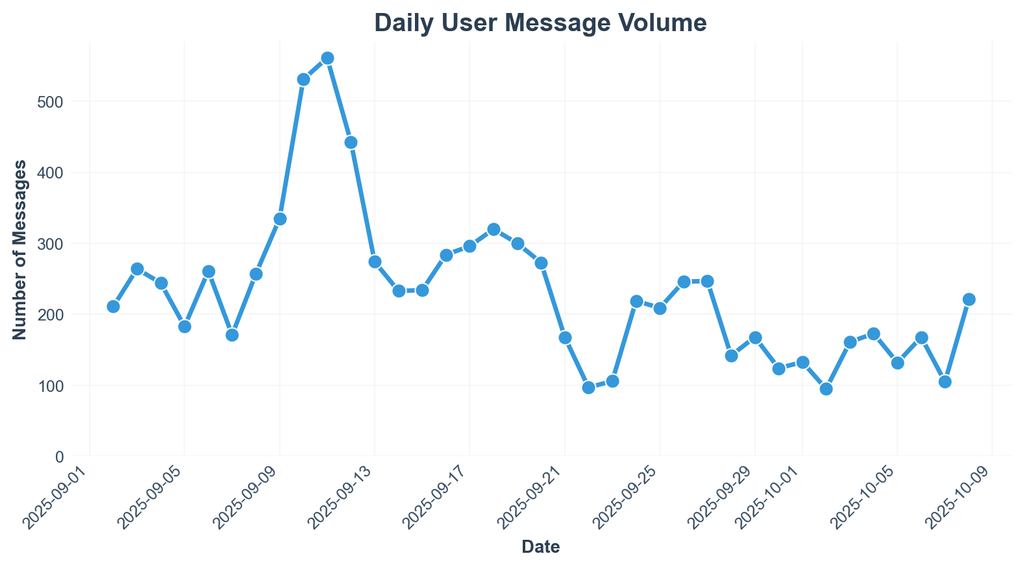

Figure 1: Daily User Message Volume Over Time

Daily message volume shows the temporal distribution of student engagement with the AI assistant.

## 1.2 Hourly Distribution

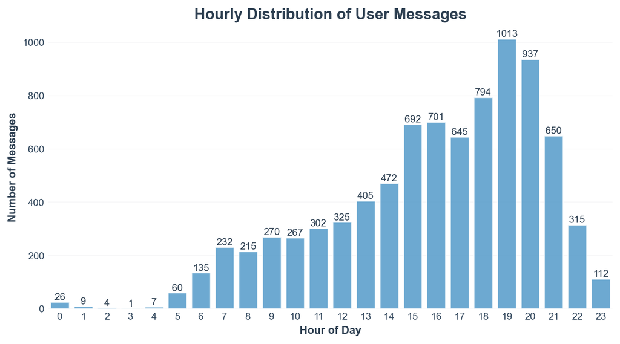

Figure 2: Hourly Distribution of User Messages Throughout the Day

This distribution reveals when students are most active in using the platform throughout the day.

## 1.3 Message Distribution by State

Table 1: Table 1.3: Message Distribution Across States with Counts and Percentages

| CAL State | Message Count | Share (%) |
| --- | --- | --- |
| haryana | 4718 | 54.9 |
| Punjab | 3300 | 38.4 |
| MP | 571 | 6.6 |

The table above shows message distribution across Indian states (Haryana, Punjab, MP, etc.), indicating which regions generate the most engagement and where students spend the most time interacting with the AI assistant.

## 1.4 Message Statistics

Table 2: Table 1.4: Summary Statistics for Message Activity

| role | messages | avg_characters | median_characters | avg_tokens | median_tokens |
| --- | --- | --- | --- | --- | --- |
| user | 8589 | 42.3574 | 38 | 7.78065 | 7 |
| assistant | 5899 | 356.919 | 423 | 56.3922 | 67 |

# Part 2: Sentiment Analysis

Sentiment analysis examines the emotional tone of messages exchanged between students and the AI assistant. Understanding sentiment helps assess user satisfaction and the quality of AI responses.

## Understanding Sentiment Analysis

**What is being measured?**

**Methodology (click to expand)**

The sentiment analysis pipeline employs transformer-based natural language processing models to assess the emotional content of conversational messages. The process unfolds in the following sequence:

**Technical Details (click to expand)**

**Specific Models Used:**

This analysis uses the `nlptown/bert-base-multilingual-uncased-sentiment` model from Hugging Face, a BERT-based sentiment classifier with the following characteristics:

- **Architecture**: Base-sized BERT (12 layers, 768 hidden dimensions, ~110 million parameters)
- **Multilingual capability**: Trained to support English, Spanish, Hindi, Punjabi, and Hinglish, making it well-suited for analyzing messages that may contain code-switched or mixed-language content common in educational settings
- **Output format**: Produces 5-point sentiment ratings (“1 star”, “2 stars”, “3 stars”, “4 stars”, “5 stars”) with confidence scores (0.0-1.0)
- **Token limit**: Messages are truncated to a maximum of 512 tokens to fit the model’s input constraints

**Engineering and Processing:**

The sentiment analysis pipeline (`scripts/04_sentiment_analysis.py`) implements the following workflow:

1. **Batch processing**: Messages are processed in batches (default: 16 messages per batch) for computational efficiency. This approach balances memory usage with throughput, allowing the pipeline to scale to thousands of messages while maintaining reasonable processing time.
2. **Separate role-based analysis**: User and assistant messages are analyzed independently, producing separate outputs:
   - User sentiment stored in `sentiment_user.csv`
   - Assistant sentiment stored in `sentiment_ai.csv`
   - This separation enables direct comparison of emotional tone between participants
3. **Output schema**: For each message, the pipeline captures:
   - `sentiment_label`: The raw model output (e.g., “4 stars”)
   - `sentiment_score`: The model’s confidence in this classification (0.0-1.0)
   - `sentiment_stars`: A normalized numeric rating (1-5 scale) extracted from the label
4. **Aggregation and statistics**: Beyond per-message classification, the pipeline computes aggregate statistics:
   - Distribution of sentiments across each role
   - Mean and median sentiment scores
   - Sentiment label frequency counts
   - These summaries are stored in `sentiment_overview.csv` for quick reference

**Model Configuration:**

The model is used with default Hugging Face `pipeline` parameters: - `truncation=True`: Longer messages are automatically truncated to 512 tokens - No custom fine-tuning is applied; the model uses its pre-trained weights as distributed by Hugging Face - The multilingual nature of the base model means it gracefully handles English, mixed-language, and code-containing messages without requiring language-specific preprocessing

**Data Flow in Pipeline:**

Sentiment analysis is the fourth step in the complete analysis pipeline: 1. Load and clean data 2. Translate messages to English (if needed) 3. Generate summary statistics 4. **→ Sentiment analysis** (this step) 5. Topic modeling 6. Agency scoring 7. Generate HTML report

Output files are stored in `data/analysis/` and are consumed by subsequent pipeline steps and the final report visualization.

## 2.1 Sentiment Comparison

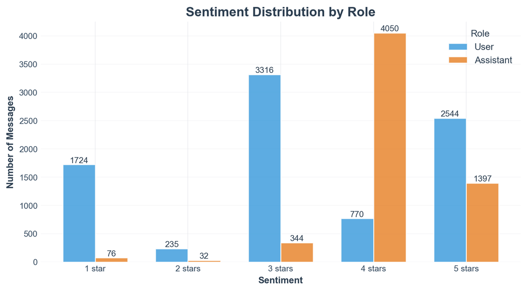

Figure 3: Sentiment Distribution Comparison Between User and AI Messages

This comparison reveals whether users and the AI assistant maintain different emotional tones during interactions.

## 2.2 Overall Sentiment Summary

Table 3: Table 3.2: Overall Sentiment Statistics

| role | messages | mean_score | median_score | mean_stars | count_3_stars | count_5_stars | count_1_star | count_4_stars | count_2_stars |
| --- | --- | --- | --- | --- | --- | --- | --- | --- | --- |
| user | 8589 | 0.334235 | 0.304305 | 3.25323 | 3316 | 2544 | 1724 | 770 | 235 |
| assistant | 5899 | 0.461413 | 0.464319 | 4.129 | 344 | 1397 | 76 | 4050 | 32 |

# Part 3: Topic Modeling

Topic modeling is a natural language processing technique that identifies the main themes and subjects discussed in conversations. This analysis reveals what students talk about most frequently and how the AI responds, providing insights into student concerns and the AI’s pedagogical coverage.

## Understanding Topic Modeling

**What is topic modeling?**

Topic modeling is an unsupervised machine learning approach that automatically discovers latent themes and patterns in textual data without requiring pre-labeled training examples. Each identified topic is represented by multiple dimensions including the most characteristic words (keywords), the frequency of topic occurrence (message count), and the message source (whether the topic appears in user or AI messages). This analytical approach enables us to identify common student questions, recognize recurring concerns, and understand the AI’s response patterns across different subject areas.

**Methodology: How topics are discovered (click to expand)**

The topic modeling pipeline employs BERTopic, a modern topic modeling framework that combines transformer-based embeddings with sophisticated clustering and dimensionality reduction algorithms. The complete process unfolds through the following sequential steps:

1. **Text embedding**: Each message in the dataset is converted into a high-dimensional semantic vector representation using sentence transformers (SBERT - Sentence-BERT). These dense embeddings capture the contextual and semantic meaning of the text rather than relying solely on keyword frequency or bag-of-words representations, enabling the model to understand subtle meaning even in short conversational exchanges.
2. **Dimensionality reduction**: The high-dimensional embedding space is projected into a lower-dimensional representation using UMAP (Uniform Manifold Approximation and Projection). This algorithm preserves the local and global semantic relationships between messages while reducing computational complexity, making the data more suitable for clustering algorithms while maintaining the meaningful structure of the embedding space.
3. **Clustering**: Semantically similar messages are grouped together into coherent clusters using HDBSCAN (Hierarchical Density-Based Spatial Clustering of Applications with Noise). Unlike traditional methods such as Latent Dirichlet Allocation (LDA) that require researchers to pre-specify the number of topics, HDBSCAN automatically determines the optimal number of topics based on the density structure of the embedding space, resulting in more natural topic divisions.
4. **Keyword extraction**: For each identified cluster, c-TF-IDF (class-based Term Frequency-Inverse Document Frequency) is applied to extract the most representative and distinctive keywords. This algorithm identifies words that are statistically frequent within a particular topic while remaining relatively rare in other topics, ensuring that extracted keywords are genuinely representative of each topic’s content.
5. **Topic refinement (optional)**: When enabled, the raw keyword lists and sample messages from each topic can be processed through OpenAI’s GPT models (such as gpt-4o-mini) to generate human-readable semantic topic labels. This optional refinement step transforms statistical keyword lists into natural language descriptions that capture the broader thematic essence of each cluster, making the results more interpretable to non-technical stakeholders.
6. **Role-based separation**: The complete topic modeling workflow is executed separately for user messages and assistant messages, enabling contrastive analysis of conversation dynamics from both participant perspectives and revealing whether the AI’s topic coverage aligns with or complements student interests.

This modern approach yields more coherent and interpretable topics compared to traditional statistical methods, particularly when analyzing conversational messages where context, nuance, and semantic meaning are crucial for accurate interpretation.

**How to interpret OpenAI-refined topics:**

When OpenAI labeling is enabled, the topic labels you see are **not** raw statistical keywords. Instead, they are natural language interpretations generated by a large language model (GPT) based on:

- The initial keyword list from c-TF-IDF
- Sample messages from the topic cluster
- Context about the domain and conversation type

**What this means for interpretation:**

- **More readable**: Topics appear as coherent phrases rather than disconnected keywords (e.g., “Business model validation strategies” instead of “business, model, validate, customer, market”)
- **Higher-level abstraction**: The LLM synthesizes the underlying theme rather than just listing common terms
- **Consistency**: Using a fixed temperature ensures deterministic, consistent labeling across runs
- **Trade-offs**: While more interpretable, OpenAI labels may occasionally oversimplify or miss nuances present in the raw keywords. For critical analysis, review both the OpenAI label and the underlying keyword distribution

**When OpenAI refinement is NOT used**, you’ll see raw keyword lists extracted via c-TF-IDF, which represent the most statistically distinctive terms for each topic. These are more granular but require more manual interpretation to understand the broader theme.

**Technical Details (click to expand)**

**Embedding Model:**

The pipeline uses `all-mpnet-base-v2`, a SentenceTransformer model optimized for semantic similarity matching across diverse text types. This multilingual model is well-suited for capturing the semantic relationships in educational discourse, including mixed-language content and technical terminology.

**BERTopic Configuration:**

The topic modeling uses BERTopic with the following component configuration:

- **Minimum topic size**: 15 messages (topics must contain at least 15 messages to be retained)
- **Calculate probabilities**: False (faster computation; topics are hard-assigned rather than probabilistic)
- **Seeded guidance**: Enabled by default with predefined topic seeds (e.g., “Registration”, “Deadlines”, “Submission”, “Business Ideas”, “Translation Help”, “Teacher Support”) to improve topic coherence

**UMAP Parameters (Dimensionality Reduction):**

```
n_neighbors: 30          # Balance between local and global structure preservation
n_components: 5          # Reduced dimensionality for clustering
min_dist: 0.1            # Tighter cluster spacing in reduced space
metric: cosine           # Distance metric optimized for text embeddings
random_state: 42         # Reproducibility
```

**HDBSCAN Parameters (Clustering):**

```
min_cluster_size: 15     # Same as min_topic_size for consistency
min_samples: 5           # Noise point sensitivity
metric: euclidean        # Distance in reduced space
cluster_selection_method: eom  # Excess of Mass (robust for varied density clusters)
cluster_selection_epsilon: 0.0 # No automatic cluster merging
prediction_data: True    # Enable probabilistic assignment
```

**CountVectorizer Parameters (Keyword Extraction):**

```
ngram_range: (1, 2)      # Include both unigrams and bigrams
min_df: 3                # Word must appear in at least 3 documents
max_df: 0.65             # Word must appear in at most 65% of documents (removes too-common words)
stop_words: Custom set   # Language-appropriate stop words
```

**OpenAI Topic Labeling:**

- **Status**: Enabled by default
- **Model**: `gpt-4o-mini` (configurable via environment variable)
- **Temperature**: 0.05 (low randomness for deterministic labeling)
- **Requires**: `OPENAI_API_KEY` environment variable

OpenAI labeling takes the extracted keywords and sample messages from each topic cluster and generates concise, human-readable semantic labels that capture the thematic essence of the cluster.

**Processing Workflow:**

- User and assistant messages are analyzed separately, generating independent topic models for each role
- Message filtering: Only messages with at least 4 tokens after cleaning are included
- Topic similarity merging: Topics with cosine similarity ≥ 0.95 are automatically merged (up to 2 merges per role)
- Output includes: topic metadata, per-message topic assignments, representative keywords, and example messages

**Output Files Generated:**

- `topic_keywords.csv` - Keywords and metadata for each topic (by role)
- `message_topics_user.csv` / `message_topics_assistant.csv` - Per-message topic assignments
- `topic_examples_user.csv` / `topic_examples_assistant.csv` - Sample messages representing each topic

## 3.1 User Message Topics

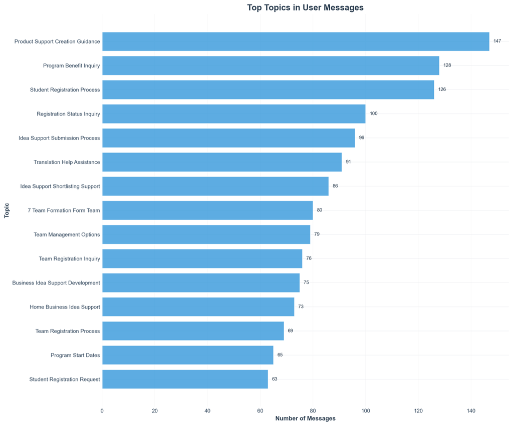

Figure 4: Top 15 Topics in User Messages

The user topic visualization reveals what students are asking about and discussing most frequently. These topics represent the primary concerns, questions, and areas where students seek assistance from the AI.

## 3.2 AI Message Topics

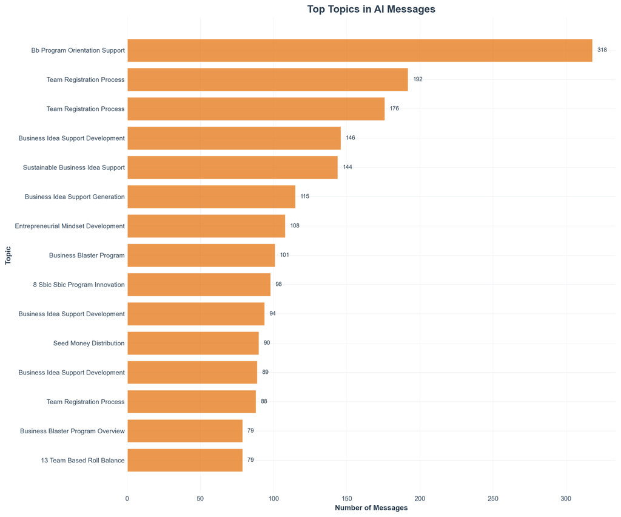

Figure 5: Top 15 Topics in AI Messages

The AI topic visualization shows the main themes in the assistant’s responses. These topics reflect how the AI is addressing student needs and what types of support it provides most frequently.

## 3.3 Interpreting Topic Patterns

To ground the topic labels and provide concrete validation of the topic clusters, the tables below display real message excerpts with topic keywords highlighted. This qualitative approach makes abstract topic interpretations tangible by showing the actual language patterns and phrasing that define each cluster. The highlighted keywords demonstrate how BERTopic identifies thematic coherence within clusters of student and assistant messages.

**Notes on topic example interpretation:**

- Keyword highlights are derived from each topic’s extracted keyword list. Since messages undergo lemmatization during preprocessing to normalize word variations, the highlighted forms may include closely related grammatical variants (e.g., “run,” “running,” “runs” are all recognized as variants of the same root concept).
- Example messages are drawn directly from the translated message corpus (the English text), providing an authentic view of how students and the AI actually phrase their contributions within each identified topic cluster.
- This qualitative grounding is essential for validating that the statistical clustering results align with human interpretation of topic coherence and semantic similarity.

### User topic examples

**Show user topic examples**

| Topic | Keywords | Example messages |
| --- | --- | --- |
| **0: Product Support Creation Guidance** | *make, product, material, making, tea, organic, made, friendly, waste, paper* | • What can we create from plastic? • Can you create a completely new product in this? • You can make jewelry from pistachio shells. |
| **1: Program Benefit Inquiry** | *benefit, program, program benefit, students, role, benefit program, program kind, role program, student program, help students* | • How will the student benefit? • What techniques can be taught to students for remembering things for the KBC program? • What will students learn through the KBC program? |
| **2: Student Registration Process** | *student bb, registration process, register bb, registration bb_program, registration, bb_program, bb, process bb_program, process, bb registration* | • What is the process for logging into the BB portal? • Where is the BB portal? • What are the registration guidelines for more than one student in the BB program? |
| **3: Registration Status Inquiry** | *registration, link, process program, check registration, registration status, site, check, registration process, link register, register* | • How do I register for KBC? • Have you completed the registration process on the KBC Sahayak portal? • My registration for KBC is done, right? |
| **4: Idea Support Submission Process** | *submit, submit idea, submission, idea, idea submission, submitted, submitting idea, submitting, idea need, submit team* | • Has the first idea been submitted? • It has been submitted. • How do I submit my idea? |
| **5: Translation Help Assistance** | *hindi, english, punjabi, access, could, change, sorry, mean, talk, like* | • How can teachers present their thoughts in Punjabi? • I’m unable to access external links. If you have any text you need translated, please paste it here. • Please type in Punjabi, BB. |
| **6: Idea Support Shortlisting Support** | *shortlisting, idea shortlisting, shortlist, shortlisting program, idea bb_program, idea, student idea, shortlisting business, program help, student shortlist* | • How can we help in shortlisting students’ ideas? • How should we shortlist ideas with students for KBC? • What feedback did EGIS kicks receive while shortlisting ideas for the KBC program? |
| **7: 7 Team Formation Form Team** | *team formation, form team, formation, form, team, effective team, team program, team form, create team, effective* | • How should the orientation and team formation for the KBC program be done? • I need tips on how to effectively manage teams in the KBC program. • What is the process for team formation in the KBC pr… |
| **8: Team Management Options** | *option, team management, team, management, create team, register team, team option, appearing, team members, create* | • How to register a team? • How can I find out my team’s name? • The team isn’t being created; it’s only showing my name. I want to create a team, how do I do it? |
| **9: Team Registration Inquiry** | *register team, team_registration, check, register, register manage, team, manage team, team_registration status, obtain, team register* | • How can I view the list of my registered team members on the KBC portal? • How to check the team registration status on the KBC portal? • How to obtain SRN for team registration on the KBC portal? |
| **10: Business Idea Support Development** | *idea program, program help, student come, help student, program student, come, business idea, program, generate, idea* | • How to develop startup ideas for students in KBC? • How to guide students in generating business ideas on the KBC program? • How can we help students develop business ideas in the KBC program? |
| **11: Home Business Idea Support** | *kind business, service, home, profit, day, type business, type, give, care, kind* | • Title: Service Provider App The main objective of this app is to provide services to people, allowing them to access services from home, saving time and avoiding the need to go outside. Initially, t… |
| **12: Team Registration Process** | *pyep udhyam, pyep, bb pyep, udhyam org, org, team bb_program, udhyam, team bb, team_registration, student team* | • How do I log in to the BB portal to manage student teams? • Are you trying to log in to the BB portal to manage student teams? • Can you provide guidance on logging into the BB portal to manage stud… |
| **13: Program Start Dates** | *program start, competition, program program, happen program, date, start program, take place, place, happen, held* | • When will the schedule for the fair’s events and competitions be released? • When will this program start? • What is the program’s starting date? |
| **15: Student Registration Request** | *another student, register another, need register, another, student registration, register, register student, student register, need registered, student want* | • After registration, can we remove any student? • Do you want to get information about your teacher registration status? • How to register a student |

### AI topic examples

**Show AI topic examples**

[output not shown]

# Part 4: Agency Scoring

Agency analysis examines how students and the AI frame their contributions during conversations. Unlike topic modeling which focuses on *what* is being discussed, agency analysis captures *how* participants express themselves—whether they adopt proactive, agentic language or more passive, low-agency communication patterns. This distinction reveals important aspects of student engagement and the AI’s pedagogical approach.

## Understanding Agency Scoring

**What is agency in conversations?**

Agency refers to the degree to which participants express themselves as active agents taking initiative, making decisions, and driving action, as opposed to passive recipients of information or instruction. In the context of student-AI interactions, high agency messages typically include:

- **Student agency**: Taking initiative in problem-solving, asking clarifying questions, proposing solutions, expressing intentions and goals
- **AI agency**: Offering guidance that empowers student decision-making, encouraging exploration and experimentation, facilitating student ownership of learning

Low-agency messages, by contrast, tend to involve passive reception, implicit requests, or statements of helplessness or dependence.

**Methodology: How agency is scored (click to expand)**

**How BERTAgent is Created (The 7 Stages)**

1. **Assemble Seed Words (ASD)**  
   Collect agency-related terms from prior dictionaries/lists (e.g., Pietraszkiewicz, Nicolas, LIWC-derived composites), then expand stems to word forms (**xASD**).
2. **Build a Lexicographic Dataset (ALD)**  
   Use the xASD words to pull synsets (definitions, lemmas, usage examples) from Open English WordNet—so the model sees words with context.
3. **Human-Rate Agency**  
   Crowd workers rate each synset/example on a 7-point low↔︎high agency scale; those ratings become training targets.
4. **Fine-Tune Transformer LMs (Regression)**  
   Train BERT/RoBERTa to predict the human agency score from text snippets; compare several dataset constructions (FT0–FT3).
5. **Create a Gold-Standard Set (GSD)**  
   Curate 300 sentences (balanced low/none/high agency) from prompted writings.
6. **Human-Rate the GSD**  
   Get ~30 ratings per sentence to obtain highly reliable ground truth.
7. **Select the Best Model**  
   Pick the model with the lowest RMSE on the held-out GSD (RoBERTa on FT3; further improved after a negation-focused re-fine-tune **rFT3**).

**Notes:**  
They also add antonym- and negation-based data augmentation and later re-fine-tune (**rFT3**) to better handle nuanced negations, which lowers RMSE further.

**How BERTAgent Produces Individual Agent Scores**

BERTAgent is packaged in Python. You pass sentences; it returns an **agency score per sentence** in the range **−1 to 1**.  
Because of token limits, it’s sentence-first; you then aggregate to the unit you care about (message, person, day, etc.).

**Clean Pipeline**

1. **Prepare per-person corpora**  
   Group all texts by individual (e.g., teacher/user).
2. **Light clean-up**  
   Normalize whitespace and sentence-split; keep punctuation (negation and emphasis matter).
3. **Score sentences**  
   Run BERTAgent on each sentence → one score in −1 to 1.
4. **Aggregate to messages**  
   Combine sentence scores per message.
   - *Mean*: overall level
   - *Max*: bursts of strong agency
   - *Min*: lowest-agency clause
5. **Aggregate to the individual**  
   Choose method(s):
   - Average or median agency across messages
   - Share of high/low agency messages
   - Time-weighted indices (recent messages count more)
   - Contextual slices (topic, channel, daypart)
6. **Stability checks**  
   Require a minimum number of messages; bootstrap confidence intervals for person-level scores.
7. **Audit edge cases**  
   Negations and sarcasm are hard—spot-check samples and consider the **rFT3** model for improved negation handling.

**Technical Details (click to expand)**

**Agency Scoring Model:**

**Scoring Process:**

1. **Input preprocessing**: Messages are normalized by reducing multiple whitespaces to single spaces. Text is truncated to a maximum of 256 whitespace-delimited tokens to fit model constraints.
2. **Batch inference**: Messages are processed in batches (default: 32) for computational efficiency. The model generates raw logits which are transformed into continuous agency scores.
3. **Score generation**:
   - Positive scores (0 to +1): Agentic language, initiative, proactive decisions
   - Negative scores (-1 to 0): Passive language, dependence, low agency
   - Near-zero scores: Minimal agency information (neutral acknowledgments, brief responses)
4. **Threshold classification**: Based on thresholds, each score is classified as:
   - **High agency**: score ≥ 0.3
   - **Low agency**: score ≤ -0.3
   - **Neutral agency**: -0.3 < score < 0.3

**Configuration Parameters:**

- **Positive threshold**: 0.3 (configurable)
- **Negative threshold**: -0.3 (configurable)
- **Batch size**: 32 messages per batch (configurable)
- **Max tokens**: 256 whitespace-delimited tokens (configurable)
- **Device**: Automatic GPU detection with CUDA support; falls back to CPU if unavailable
- **Random seed**: 42 (for reproducibility)

**Computation:**

- GPU acceleration with CUDA memory cache clearing after each batch to prevent memory leaks
- Automatic fallback to CPU inference if CUDA is unavailable
- Robust error handling for model loading (safetensors format prevents pickle vulnerabilities)

**Output Schema:**

Each message receives the following fields:

```
- message_id: Unique identifier per message
- agency_score: Continuous score (-1 to +1)
- is_high: Boolean indicating high agency (score ≥ 0.3)
- is_low: Boolean indicating low agency (score ≤ -0.3)
- message_role: "user" or "assistant"
- (original text fields preserved)
```

**Role-Based Analysis:**

- User and assistant messages are scored independently, generating separate output files
- `data/analysis/agency_user.parquet` - User message agency scores
- `data/analysis/agency_assistant.parquet` - Assistant message agency scores
- Files also preserve original datetime and WhatsApp ID if present in input

**Pipeline Integration:**

Agency scoring is the sixth step in the complete analysis pipeline: 1. Load and clean data 2. Translate messages to English 3. Generate summary statistics 4. Sentiment analysis 5. Topic modeling 6. **→ Agency scoring** (this step) 7. Generate HTML report

The agency scores are aggregated into summary statistics and visualized in the report to show comparative agency patterns between students and the AI assistant.

## 4.1 Agency Scoring Summary

Table 4: Table 4.1: Agency Scoring Statistics by Message Role

[output not shown]

## 4.2 Agency Distribution

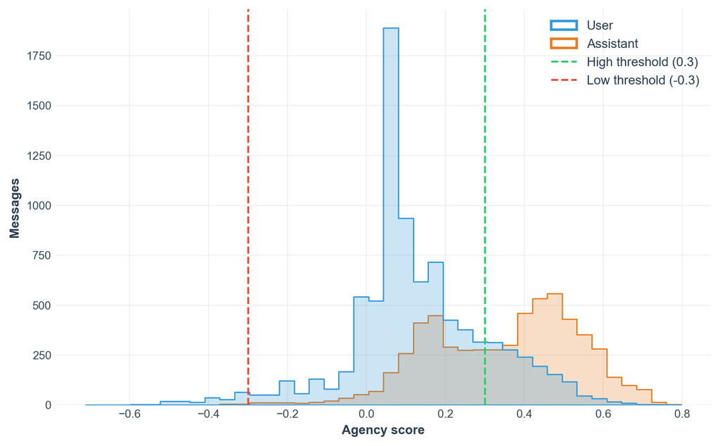

Figure 6: Distribution of Agency Scores by Message Role

## 4.3 Qualitative Examples

The following tables show messages with the highest and lowest agency scores for each participant type, providing concrete illustrations of what high-agency, low-agency, and neutral-agency communication looks like in the context of student-AI interactions:

Table 5: Top High-Agency User Messages

|  | message_id | agency_score | message |
| --- | --- | --- | --- |
| 0 | user_2667 | 0.797242 | I give my best. |
| 1 | user_4694 | 0.735063 | I am a leader. |
| 2 | user_1523 | 0.725979 | Quickly |
| 3 | user_5031 | 0.725979 | Quickly |
| 4 | user_7132 | 0.695387 | How can we finalize a business idea effectively? |

Table 6: Lowest Agency User Messages

|  | message_id | agency_score | message |
| --- | --- | --- | --- |
| 0 | user_4410 | -0.711212 | They don’t give any work. |
| 1 | user_3403 | -0.604936 | I didn’t find team management. |
| 2 | user_7807 | -0.573333 | Bro, I don’t know what needs to be done in this program. |
| 3 | user_2553 | -0.570694 | We can become bored. |
| 4 | user_4204 | -0.557953 | I can’t focus on my studies. |

Table 7: Neutral Agency User Messages

|  | message_id | agency_score | message |
| --- | --- | --- | --- |
| 0 | user_1065 | 0.0473527 | Can two students be registered with the same number? |
| 1 | user_1724 | 0.137282 | I have to register for Business Blaster. |
| 2 | user_3210 | 0.118585 | I need to register for the Tejasavi program. |
| 3 | user_1366 | 0.00984351 | The purpose of KBC |
| 4 | user_3572 | 0.0510351 | Okay |

Table 8: Top High-Agency Assistant Messages

|  | message_id | agency_score | message |
| --- | --- | --- | --- |
| 0 | assistant_7055 | 0.786163 | Through the Kushal Business Challenge (KBC), students will gain: 1. Courage and Confidence: Develop the ability to explore new ideas and take initiatives. 2. Personal and Professional Growth: Apply en… |
| 1 | assistant_6095 | 0.78546 | Through this program, students will: 1. Develop the courage and confidence to discover and initiate new ideas. 2. Promote personal and professional development by using entrepreneurial skills in real-… |
| 2 | assistant_4013 | 0.769313 | Through the Skill Business Challenge (KBC) program, students will: 1. Develop the courage and confidence to discover new ideas and take initiatives. 2. Promote personal and professional development by… |
| 3 | assistant_2219 | 0.754808 | You will gain the following benefits from the SBIC program: 1. Develop the courage and confidence to discover and initiate new ideas. 2. Achieve personal and professional growth by applying entreprene… |
| 4 | assistant_8357 | 0.750225 | The KBC program starts in the second week of July 2025. It helps students by: 1. Developing courage and confidence to explore new ideas. 2. Enhancing personal and professional growth through real-life… |

Table 9: Lowest Agency Assistant Messages

|  | message_id | agency_score | message |
| --- | --- | --- | --- |
| 0 | assistant_7988 | -0.410046 | Sorry, but I cannot help with the registration process. You can visit your school or institution’s website to see the registration instructions. If you have any specific questions, I am ready to help. |
| 1 | assistant_1783 | -0.379582 | There can be some common issues in the student team registration process: 1. **Incomplete Information:** Students are not filling in the necessary information, such as team members’ names or contact d… |
| 2 | assistant_2877 | -0.36857 | There could be several potential reasons for not participating in KBC (Kushal Business Challenge): 1. **Lack of Time:** Students may have other academic or personal commitments. 2. **Lack of Interest:… |
| 3 | assistant_6060 | -0.362536 | I apologize, but I cannot assist with site issues or technical support. Please contact your school’s IT department or the official support team of the BB program. If you have any other questions relat… |
| 4 | assistant_3803 | -0.356077 | I am sorry, but I cannot remove myself from team management. If you need any assistance related to team management, please contact your teacher or program coordinator. They can guide you in the right … |

Table 10: Neutral Agency Assistant Messages

|  | message_id | agency_score | message |
| --- | --- | --- | --- |
| 0 | assistant_7545 | 0.139623 | In the KBC program, when students submit their startup ideas, they do not need to provide any information related to funding. They only need to provide detailed information about two ideas that they h… |
| 1 | assistant_4637 | 0.0539383 | Only one student can be registered with a single phone number. Each student must register using their personal phone number so that their progress and activities can be tracked accurately. If a studen… |
| 2 | assistant_3336 | -0.141168 | Sorry, I cannot confirm the registration status for your brother in the KBC program at this time. Please contact your school teacher or visit the KBC portal (https://kbc-haryana.udhyam.org/) for more … |
| 3 | assistant_8076 | -0.0108318 | The link to the KBC portal is: https://KBC-haryana.udhyam.org/. You will find all the information related to the program on this portal. If you need more information, feel free to ask! |
| 4 | assistant_7779 | 0.0951365 | This program is for students of 11th and 12th grade studying in government schools and PM Shri schools of Haryana. These students are getting the opportunity to learn and showcase their entrepreneuria… |

By analyzing these patterns over time, educators can identify which topics require enhanced content, where students struggle most, and how to optimize the AI’s pedagogical approach.

# Summary and Recommendations

This analysis provides comprehensive insights into how students interact with the AI assistant on the Udhyam learning platform. By examining message patterns, sentiment, topics, and engagement dynamics, we have identified key trends that can guide platform improvements and optimize the learning experience.

## Key Insights

**Engagement Volume:** Student engagement is substantial, with a total of 8,589 messages exchanged over the analysis period. Peak activity occurs around hour 19, indicating a concentrated window of student engagement that should be considered when scheduling support and platform maintenance.

**Geographic Focus:** The ‘haryana’ region is the primary focus of student interactions, generating 4,718 messages. This high-volume region represents a critical area where students spend most of their time and where the AI assistant provides the most support. Optimizing content and AI responses for this region could yield significant improvements in student outcomes.

**Emotional Tone:** Student sentiment is predominantly 3 stars, reflecting their emotional state when interacting with the platform. The AI assistant maintains a 4 stars tone in its responses, demonstrating consistent emotional support. Maintaining or improving this positive interaction dynamic is essential for student satisfaction and engagement.

**Primary Discussion Areas:** Student discussions are concentrated around specific topics, with ‘make, product, material, making, tea, organic, made, friendly, waste, paper’ being the most frequently discussed area with 147 messages. This concentration indicates clear student interests and pain points that represent opportunities for targeted content development and AI response optimization.

**Report generated:** October 28, 2025

**Analysis period:** 2025-09-02T13:59:14 to 2025-10-08T20:13:54

**Total messages analyzed:** 8,589